# data 시각화

### data시각화: Matplotlib , seabon라이브러리를 사용

### matplotlib 을 이용

파이썬으로 기본적 차트들을 쉽게 그릴수 있도록 도와주는 가장 유명한 데이터 시각화 라이브러리

https://matplotlib.org/

### seaborn 을 이용

Matplotlib을 기반으로 다양한 색상 테마와 통계용 차트 등의 기능을 추가한 시각화 패키지

https://seaborn.pydata.org/  
https://github.com/mwaskom/seaborn-data  
python 3.6+  
pip instsall seaborn  
conda install seaborn

#### 많이 사용하는 샘플 데이터

iris = sns.load_dataset("iris")  
titanic = sns.load_dataset("titanic")  
tips = sns.load_dataset("tips")  
flights = sns.load_dataset("flights")

https://scikit-learn.org/stable/datasets/index.html

Iris plants dataset  
iris = sns.load_dataset("iris")

Wine recognition dataset

https://www.kaggle.com/

## 1. matplotlib 을 이용

```python
import matplotlib as pml
import matplotlib.pyplot as plt

pml.__version__
```

```
'3.2.2'
```

```python
%matplotlib inline
```

#### basic line plot : 선그래프

데이터 변화를 시각화 하는데 유용

#### plot : line이나 marker로 x대 y 차트를 그림

#### https://matplotlib.org/3.1.1/api/_as_gen/matplotlib.pyplot.plot.html#matplotlib.pyplot.plot

#### #### plot([x], y, [fmt], *, data=None, **kwargs)

plot([x], y, [fmt], [x2], y2, [fmt2], ..., **kwargs)

fmt = '[marker][line][color]'

https://matplotlib.org/examples/showcase/anatomy.html

[figure not shown]

라인플롯

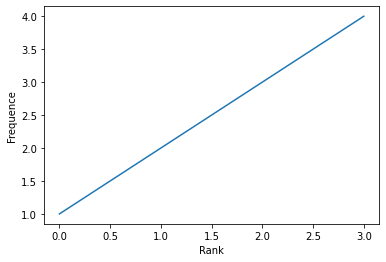

```python
import matplotlib.pyplot as plt

plt.plot([1, 2, 3, 4])
plt.ylabel('Frequence')
plt.xlabel('Rank')
plt.show()
```

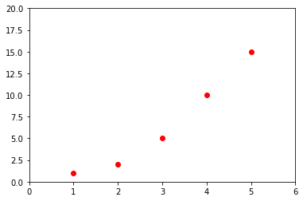

```python
plt.plot([1, 2, 3,4,5 ], [1, 2, 5,10,15], 'ro') ## x축 값과 y축값을 입력
plt.axis([0,6,0,20])  # x축 최소  y축 최대
plt.show()
```

```python
import numpy as np
x=np.linspace(0,5, 11)
x
```

```
array([0. , 0.5, 1. , 1.5, 2. , 2.5, 3. , 3.5, 4. , 4.5, 5. ])
```

```python
y=x**2
```

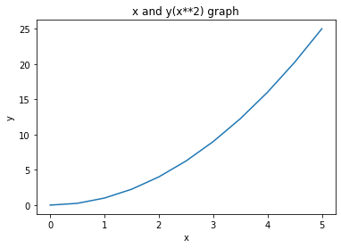

```python
plt.plot(x, y)
plt.xlabel('x')
plt.ylabel('y')
plt.title('x and y(x**2) graph')

plt.show()
```

#### 한글깨짐 방지

```python
import platform
import sys
platform.system()

sys.platform
```

```
'win32'
```

linux platform => linux, linux2 os x => darwin platform window => win32, win64

```
win32
```

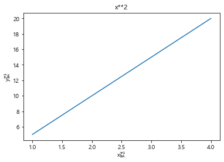

```python
import sys
import numpy as np
import matplotlib.pyplot as plt
import matplotlib as mpl
print(sys.platform)
fontname=np.nan;
if sys.platform in ['win32', 'win64']:
    fontname="malgun gothic"


mpl.font_manager._rebuild()

x=np.arange(1,5)
y=x*5
plt.plot(x,y)
plt.rc('font', family=fontname)

plt.xlabel('x값')
plt.ylabel('y값')
plt.title('x**2')
```

[output not shown]

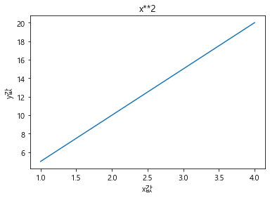

```python
import matplotlib
import matplotlib.font_manager as fm
import numpy as np
import matplotlib.pyplot as plt

x=np.arange(1,5)
y=x*5

path = 'C:/Windows/Fonts/malgunbd.ttf'
font_name = fm.FontProperties(fname=path, size=50).get_name()
print(font_name)
plt.rc('font', size=11, family=font_name)

plt.plot(x,y)
plt.xlabel('x값')
plt.ylabel('y값')
plt.title('x**2')
```

#### 다수의 그래프 그리기

#### https://matplotlib.org/3.1.1/api/_as_gen/matplotlib.pyplot.plot.html#matplotlib.pyplot.plot

fmt = '[marker][line][color]'

[figure not shown]

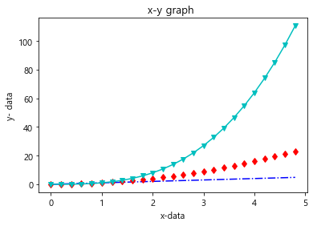

```python
import numpy as np
import matplotlib.pyplot as plt
import matplotlib as mpl

mpl.font_manager._rebuild()
t = np.arange(0., 5., 0.2)
plt.plot(t, t,'b-.', t, t**2,'rd', t, t**3,'cv-')
plt.xlabel('x-data')
plt.ylabel('y- data')
plt.title('x-y graph ')
plt.show()
```

[output not shown]

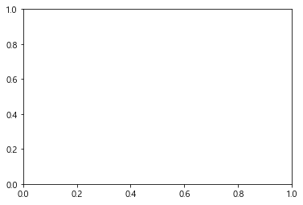

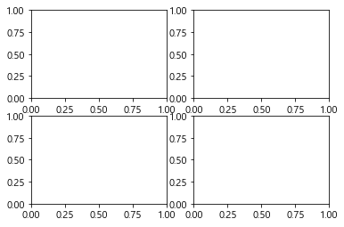

```python
import numpy as np
import matplotlib.pyplot as plt

import matplotlib as mpl

mpl.font_manager._rebuild()
fig = plt.figure()
plt.subplots()
plt.subplots(2, 2)
```

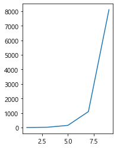

```python
import numpy as np
import matplotlib.pyplot as plt

x1=np.arange(1,5)
y1=x1**3

x2=np.arange(1,10,2)
y2=np.exp(x2)

plt.plot(x1,y1)
plt.grid(True)
plt.subplot(1,2,2)
plt.plot(x2,y2)

plt.grid(False)
```

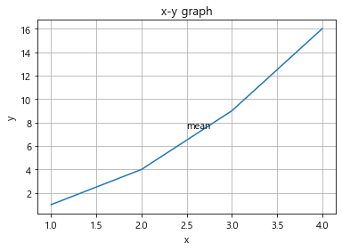

```python
import numpy as np
import matplotlib.pyplot as plt
import matplotlib as mpl

mpl.font_manager._rebuild()

x=np.arange(1,5)
y=x**2

plt.plot(x, y)
plt.xlabel('x')
plt.ylabel('y')
plt.title('x-y graph')
plt.text(np.mean(x), np.mean(y),'mean')
plt.grid(True)
plt.show()
```

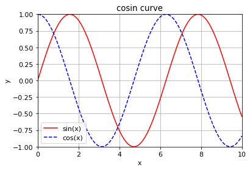

```python
import numpy as np
import matplotlib.pyplot as plt


plt.rc('font',family="malgungothic")
x=np.linspace(0,10,100)

plt.xlim(0,10)
plt.ylim(-1,1)

plt.title('cosin curve')
plt.xlabel('x')
plt.ylabel('y')

plt.plot(x, np.sin(x),'r-', label='sin(x)')
plt.plot(x, np.cos(x),'b--', label='cos(x)')

plt.grid(True)
plt.legend()

plt.show()
```

#### Figure : 숫자, 수치

#### Axes : 플롯 : 데이터 공간이 이미지영역

```
데이터 제한을 처리하는 2개(3차원일 경우 3개)
  set_xlim() set_ylim()   set_title set_xlabel set_ylabel()
```

#### Axis : 숫자 선 같은 객체

그래프 한계선을 설정하고 눈금(축표시)과 눈금(문자열)을 생성

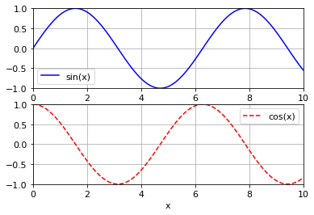

```python
import numpy as np
import matplotlib.pyplot as plt
import matplotlib.font_manager

x=np.linspace(0,10,100)
plt.subplot(2,1,1)
plt.plot(x, np.sin(x),'b-', label='sin(x)')

plt.axis([0,10,-1,1])
#plt.axis('equal')
plt.legend()
plt.xlabel('x')
plt.grid(True)

plt.subplot(2,1,2)
plt.plot(x, np.cos(x),'r--', label='cos(x)')
plt.axis([0,10,-1,1])
#plt.axis('equal')
plt.legend()

plt.xlim(0,10)  # set_xlim() x의 범위 숫자를 통해
plt.ylim(-1,1)

plt.xlabel('x')
plt.grid(True)

plt.show()
```

#### 파이 그래프

Figure : The top level container for all the plot elements.  
axes.Axes : The Axes contains most of the figure elements  
startangle :자료의 시작 각도

axis('equal') : 원

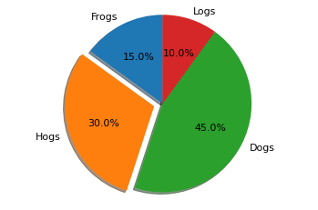

```python
import matplotlib.pyplot as plt


labels = 'Frogs', 'Hogs', 'Dogs', 'Logs'
sizes = [15, 30, 45, 10]
explode = (0, 0.1, 0, 0)

fig1, ax1 = plt.subplots()
ax1.pie(sizes, explode=explode, labels=labels, autopct='%1.1f%%',
        shadow=True, startangle=90)
ax1.axis('equal')   #원으로 표현  axis() 기본은 타원
plt.show()
```

#### 막대 그래프 (Bar graph, Bar chart) : 범주가 있는 데이터 값을 직사각형의 막대로 표현하는 그래프

bar 함수 사용

bar(x, height, width=0.8, bottom=None, *, align='center', data=None, **kwargs)

https://matplotlib.org/api/_as_gen/matplotlib.pyplot.bar.html?highlight=bar#matplotlib.pyplot.bar

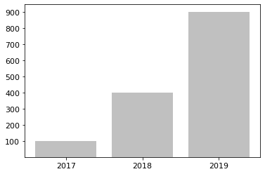

```python
import matplotlib.pyplot as plt
import numpy as np

x = np.arange(3)
years = ['2017', '2018', '2019']
values = [100, 400, 900]

plt.bar(years,values,color='silver')
plt.yticks(ticks=np.arange(100, 1000, 100))
#plt.xticks(ticks=years)
plt.show()
```

수평막대 그래프 범주가 있는 데이터 값을 수평방향의 막대료 표현

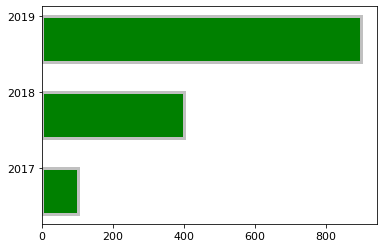

```python
import matplotlib.pyplot as plt
import numpy as np

y = np.arange(3)
years = ['2017', '2018', '2019']
values = [100, 400, 900]

plt.barh(y, values, height=-0.6, align='edge', color="green",
        edgecolor="silver", linewidth=3, tick_label=years, log=False)
plt.show()
```

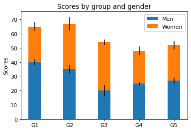

```python
import matplotlib.pyplot as plt

labels = ['G1', 'G2', 'G3', 'G4', 'G5']
men_means = [40, 35, 20, 25, 27]
women_means = [25, 32, 34, 23, 25]
men_std = [2, 3, 4, 1, 2]
women_std = [3, 5, 2, 3, 3]
width = 0.35       # the width of the bars: can also be len(x) sequence

fig, ax = plt.subplots()

ax.bar(labels, men_means, width, yerr=men_std, label='Men')
ax.bar(labels, women_means, width, yerr=women_std, bottom=men_means,
       label='Women')

ax.set_ylabel('Scores')
ax.set_title('Scores by group and gender')
ax.legend()

plt.show()
```

#### 산점도(scatter plot )

두 변수의 상관 관계를 직교 좌표계의 평면에 데이터를 점으로 표현하는 그래프

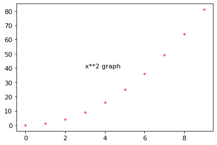

```python
import numpy as np
import matplotlib.pyplot as plt

N = 50
x=np.arange(10)
y=x**2
area=10  # 점의 크기
plt.scatter(x, y, s=area, c='red', alpha=0.5)
plt.text(3,40,'x**2 graph')
plt.show()
```

#### numpy np.random

np.random.randint : 균일분포의 정수 난수 1개 생성  
np.random.rand: 0부터 1사이의 균일분포에서 난수 생성  
np.random.randn: 가우시안 표준 정규분포에서 난수 생성

import numpy as np  
import matplotlib.pyplot as plt  
np.random.seed(19680801)

mu, sigma = 100, 15  
x = mu + sigma * np.random.randn(10000) #평균이 100 표준편차 15인 정규분포

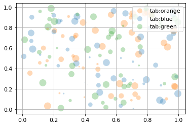

```python
import numpy as np
np.random.seed(19680801)
import matplotlib.pyplot as plt


fig, ax = plt.subplots()
for color in ['tab:orange','tab:blue', 'tab:green']:
    n = 50
    x, y = np.random.rand(2, n)
    scale = 200.0 * np.random.rand(n)
    ax.scatter(x, y, c=color, s=scale, label=color,
               alpha=0.3, edgecolors='none')

ax.legend(loc="upper right")
ax.grid(True)

plt.show()
```

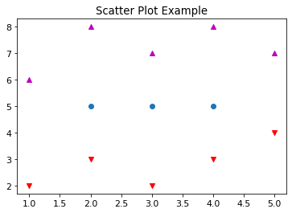

```python
import matplotlib.pyplot as plt

x1 = [2, 3, 4]
y1 = [5, 5, 5]

x2 = [1, 2, 3, 4, 5]
y2 = [2, 3, 2, 3, 4]
y3 = [6, 8, 7, 8, 7]

# Markers: https://matplotlib.org/api/markers_api.html

plt.scatter(x1, y1)
plt.scatter(x2, y2, marker='v', color='r')
plt.scatter(x2, y3, marker='^', color='m')
plt.title('Scatter Plot Example')
plt.show()
```

### scatter matrix

```
   sepal_length  sepal_width  petal_length  petal_width species
0           5.1          3.5           1.4          0.2  setosa
1           4.9          3.0           1.4          0.2  setosa
2           4.7          3.2           1.3          0.2  setosa
3           4.6          3.1           1.5          0.2  setosa
4           5.0          3.6           1.4          0.2  setosa
```

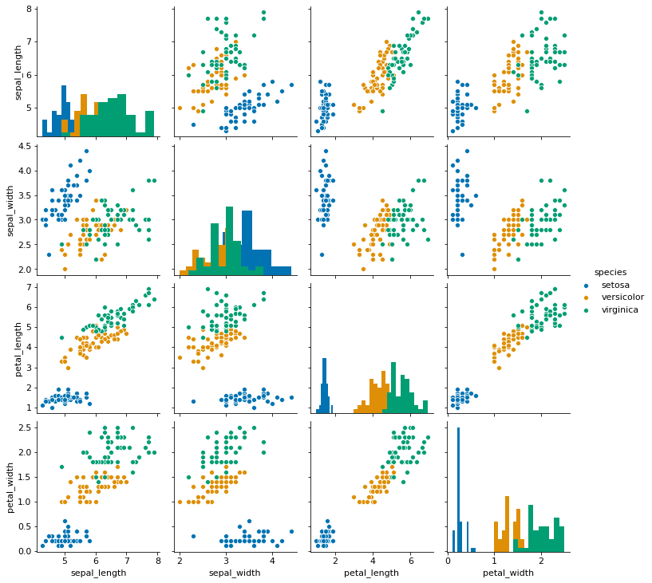

```python
import numpy as np
import pandas as pd

import matplotlib.pyplot as plt
import seaborn as sns
iris = sns.load_dataset('iris')
print(iris.head())

sns.pairplot(iris,diag_kind='hist',hue="species",palette='colorblind')   #diag_kind='kde'
plt.show()
```

=> sepal_length와 sepal_width, petal_length, patal_width에서 setossa를 구분했으나  
petal_length와 patal_width에서 비교적 잘 setosa를 구분했다.  
=> versicolor, virginica는 구분이 어렵다.

=>petal_length는 sepal_length, petal width 와 상관관계가 높고,  
sepal_length는 patal_length petal_width 와 상관관계가 높다.

#### 히스토그램 (Histogram) :값의 빈도를 보여주는 그래프

Plot a histogram.

도수분포표를 그래프로 나타낸 것으로서, 가로축은 계급, 세로축은 도수 (횟수나 개수 등)등을 표현

https://matplotlib.org/3.1.1/gallery/statistics/hist.html#sphx-glr-gallery-statistics-hist-py

matplotlib.pyplot.hist(x, bins=None, range=None, density=None, weights=None, cumulative=False, bottom=None, histtype='bar', align='mid', orientation='vertical', rwidth=None, log=False, color=None, label=None, stacked=False, normed=None, *, data=None, **kwarg)

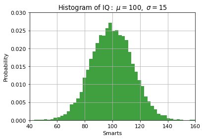

```python
import numpy as np
import matplotlib.mlab as mlab
import matplotlib.pyplot as plt

mu, sigma = 100, 15  # mu:평균  sigma: 표준편차
x = mu + sigma*np.random.randn(10000)
# the histogram of the data

plt.hist(x, 50, density=True, color='green', alpha=0.75)
plt.xlabel('Smarts')
plt.ylabel('Probability')
plt.title(r'$\mathrm{Histogram\ of\ IQ:}\ \mu=100,\ \sigma=15$')
plt.axis([40, 160, 0, 0.03])
plt.grid(True)

plt.show()
```

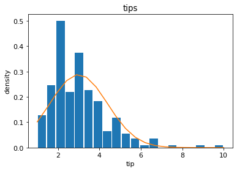

```python
import matplotlib.pyplot as plt
import seaborn as sns
import numpy as np
import scipy as sp

tips=sns.load_dataset('tips')

bins=20
plt.hist(x=tips.tip, rwidth=0.9, bins=bins, density=True)
plt.title('tips')
plt.xlabel('tip')
plt.ylabel('density')
mu, sigma=tips.tip.mean(), tips.tip.std()

tip_min=tips.tip.min()
tip_max=tips.tip.max()

x=np.linspace(tip_min, tip_max, bins)
y=sp.stats.norm(mu,sigma).pdf(x)
plt.plot(x, y)
```

### 박스 플롯

최소값, 제1사분위수, 2사분위수(중앙값) 3사분위수, 최대값

이상치 : 아웃라이어(outlier)  
통계적 자료분석의 결과를 왜곡시키거나, 자료 분석의 적절성을 위협하는 변수값 또는 사례  
개체의 변수값이 0(평균)으로부터 ±3 표준편차밖에 위치하는 사례 일반적인 경향에서 벗어나는 사례

정규분포

[figure not shown]

https://en.wikipedia.org/wiki/Standard_score#/media/File:The_Normal_Distribution.svg

박스플롯 IQR 방식은 75% percentile + 1.5 IQR 이상이거나  
25 percentile - 1.5 IQR 이하인 경우 극단치로 처리하는 방식

[figure not shown]

이상값 탐지를 위한 시각화 방법  
히스토그램( 한 변수의 이상값 분석, 정규 분포 양극단) 박스 플롯 산점도(두 변수의 이상값)

```python
import pandas as pd
import numpy as np
import matplotlib.pyplot as plt
import seaborn as sns
iris=sns.load_dataset('iris')

print(iris)
st = iris.groupby('species').mean()
print(st)
```

```
     sepal_length  sepal_width  petal_length  petal_width    species
0             5.1          3.5           1.4          0.2     setosa
1             4.9          3.0           1.4          0.2     setosa
2             4.7          3.2           1.3          0.2     setosa
3             4.6          3.1           1.5          0.2     setosa
4             5.0          3.6           1.4          0.2     setosa
..            ...          ...           ...          ...        ...
145           6.7          3.0           5.2          2.3  virginica
146           6.3          2.5           5.0          1.9  virginica
147           6.5          3.0           5.2          2.0  virginica
148           6.2          3.4           5.4          2.3  virginica
149           5.9          3.0           5.1          1.8  virginica

[150 rows x 5 columns]
            sepal_length  sepal_width  petal_length  petal_width
species
setosa             5.006        3.428         1.462        0.246
versicolor         5.936        2.770         4.260        1.326
virginica          6.588        2.974         5.552        2.026
```

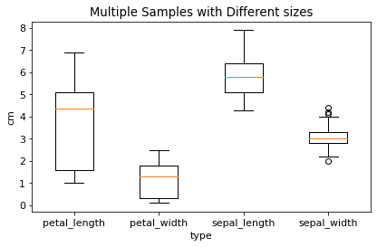

```python
import pandas as pd
import numpy as np
import matplotlib.pyplot as plt
import seaborn as sns
import matplotlib.font_manager

plt.title('Multiple Samples with Different sizes')
plt.boxplot((iris['petal_length'], iris['petal_width'],iris['sepal_length'],iris['sepal_width']))
plt.tight_layout(pad=2, h_pad=1) # pad: 박스플랏과 제목 사이 간격, h_pad: 1행 2행 사이 간격
plt.xticks([1,2,3,4], ['petal_length','petal_width','sepal_length','sepal_width'])
plt.rc('font', size=5)
plt.xlabel("type")
plt.ylabel("cm")
plt.show()
```

## 2.seaborn

#### matplotlib을 기반으로 만들어져 통계 데이터 시각화에 최적화된 라이브러리

http://seaborn.pydata.org/

seaborn data들  
https://github.com/mwaskom/seaborn-data

import seaborn as sns 각 데이터 읽기

iris=sns.load_dataset('iris')  
titanic=sns.load_dataset('titanic')  
tips=sns.load_dataset('tips')  
flights=sns.load_dataset('flights') "

### seaborn사용이 안될때

conda remove --force numpy, scipy

pip install numpy

pip install scipy

pip install seaborn

#### 1차원 데이터 : 실수값, 실수분포

rugplot, kdeplot, distplot,countplot

#### 다차원 데이터:

2차원 실수 : 스캐터 플롯(joinplot) -카테고리형 포함시 hue속성지정  
2차원 카테고리 : heatmap  
2차원 실수값, 카테고리가 혼재  
barplot, boxplot, pointplot, violinplot, swarmplot  
3차원이상 실수형 : pairplot(그리드형)

### rugplot

실수 분포 플롯으로 데이터 위치를 x축 위에 작은 선분(rug)으로 나타내어  
실제 데이터의 위치를 표시함

http://seaborn.pydata.org/generated/seaborn.rugplot.html

```python
iris.head()
```

|  | sepal_length | sepal_width | petal_length | petal_width | species |
| --- | --- | --- | --- | --- | --- |
| 0 | 5.1 | 3.5 | 1.4 | 0.2 | setosa |
| 1 | 4.9 | 3.0 | 1.4 | 0.2 | setosa |
| 2 | 4.7 | 3.2 | 1.3 | 0.2 | setosa |
| 3 | 4.6 | 3.1 | 1.5 | 0.2 | setosa |
| 4 | 5.0 | 3.6 | 1.4 | 0.2 | setosa |

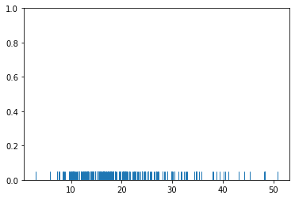

```python
import seaborn as sns
import matplotlib.font_manager as fm
import seaborn as sns
import matplotlib.pyplot as plt

%matplotlib inline

plt.rc('font', family='malgungothic')
tips=sns.load_dataset('tips')
sns.rugplot(tips['total_bill'] )
```

### kdploat :커널 밀도(kernel density)

histogram : 구간을 나눠서 막대그래프로 그림  
구간 설정에 따라 결과가 달라지고 불연속성이 나타남

=> 대안: 커널 밀도 추정(KDE : Kernel Density Estimator)

- density estimation(밀도추정) -확률밀도  
  데이터들의 분포로부터 원래 변수(확률) 분포의 특성을 추정하는 것
- 커널함수 : 원점을 중심으로 대칭이며 적분이 1인 non-negative 함수  
  대표적: uniform, gaussian

### displot: hist그래프와 kdplot을 통합한 그래프

http://seaborn.pydata.org/generated/seaborn.distplot.html

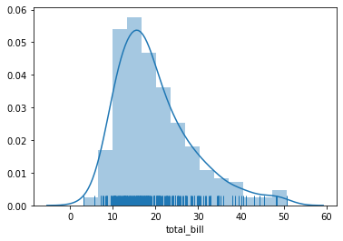

```python
import seaborn as sns
import matplotlib.font_manager

%matplotlib inline

tips=sns.load_dataset('tips')
sns.distplot( tips['total_bill'], rug=True, kde=True )
```

#### 카운트 플롯(countplot)

각 카테고리 값 별로 데이터가 얼마나 있는지 표시

```python
import pandas as pd
import seaborn as sns


titanic=sns.load_dataset('titanic')

df=pd.DataFrame(titanic)

df.groupby('class')['survived'].count()
```

```
class
First     216
Second    184
Third     491
Name: survived, dtype: int64
```

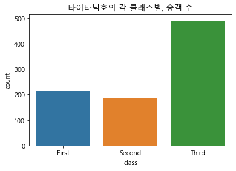

```python
import seaborn as sn
import matplotlib.font_manager
import matplotlib.pyplot as plt
import sys
import pandas as pd


titanic=sns.load_dataset('titanic')
sns.countplot(x="class", data=titanic)


if sys.platform in ['win32', 'win64'] :
    font_name='malgungothic'

plt.rc('font',size=11, family=font_name)
matplotlib.font_manager._rebuild()

plt.title("타이타닉호의 각 클래스별, 승객 수")



plt.show()
```

### joinplot

scatter 플롯 뿐 아니라 각 축별로 히스토그램을 같이 보여줌

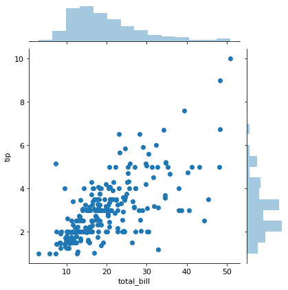

```python
import seaborn as sns
import matplotlib.pyplot as plt
import matplotlib.font_manager



sns.jointplot(x='total_bill', y='tip',data=tips) #kind="kde"
plt.show()
```

### heatmap

열을 의미하는 heat와 map이 합친 단어이다.  
두개의 카테고리 값에 대한 값 변화를 한눈이 알기 쉽다.

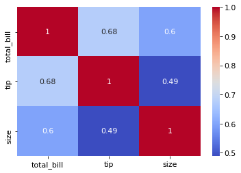

```python
cor=tips.corr()
sns.heatmap(cor,annot=True, cmap='coolwarm',)
```

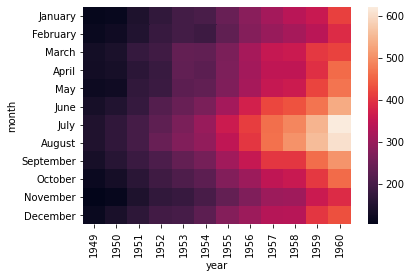

```python
import numpy as np
import matplotlib.pyplot as plt
import seaborn as sns
import matplotlib.font_manager as fc

flights=sns.load_dataset('flights')
df=flights.pivot('month','year','passengers')


sns.heatmap(df)
plt.show()
```

### barplot

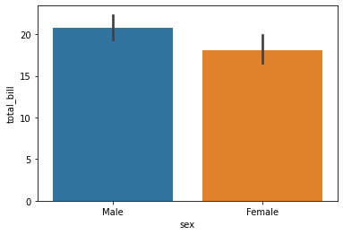

```python
import seaborn as sns

tips=sns.load_dataset('tips')
sns.barplot(x='sex',y='total_bill',data=tips)
```

### pairplot

3차원 이상의 데이터일 경우 분포도를 그림  
각 카테고리들의 상관관계를 출력

https://seaborn.pydata.org/generated/seaborn.pairplot.html

diag_kind='kde' or dia_kind='hist'

https://seaborn.pydata.org/tutorial/color_palettes.html

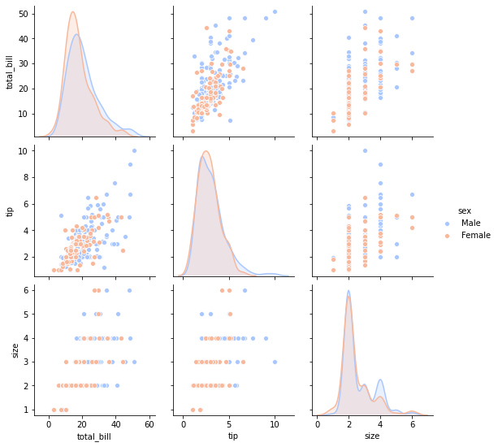

```python
sns.pairplot(tips,hue='sex' ,palette='coolwarm' )
```

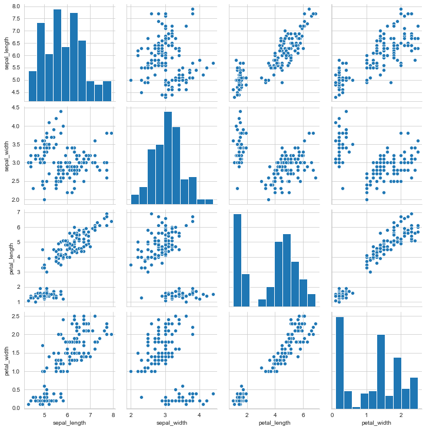

```python
import numpy as np
import seaborn as sns
import matplotlib.pyplot as plt

sns.set_style("whitegrid")

iris = sns.load_dataset("iris")

sns.pairplot(iris)
plt.show()
```